# 02_sunset_shadow_speed

## 02_sunset_shadow_speed

#### Question

1. At sunset, the sun’s rays are parallel to the local flat ground. A rocket is launched at an angle of elevation of 32.3° above the horizon at a speed of 3120 meters per second. Its shadow is projected onto a tall vertical cliff to the east.

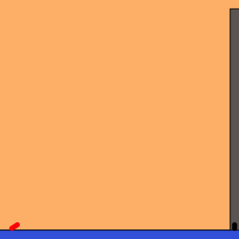

   How fast, in meters per second, is the shadow moving up the cliff? The tolerance is $\pm 10$ m/s.

#### Question

2. At sunset, the sun’s rays are parallel to the local flat ground. A rocket is launched at an angle of elevation of 48.9° above the horizon at a speed of 4720 meters per second. Its shadow is projected onto a tall vertical cliff to the east.

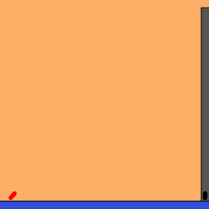

   How fast, in meters per second, is the shadow moving up the cliff? The tolerance is $\pm 10$ m/s.

#### Question

3. At sunset, the sun’s rays are parallel to the local flat ground. A rocket is launched at an angle of elevation of 28.9° above the horizon at a speed of 4700 meters per second. Its shadow is projected onto a tall vertical cliff to the east.

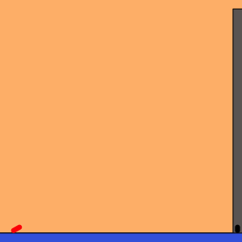

   How fast, in meters per second, is the shadow moving up the cliff? The tolerance is $\pm 10$ m/s.

#### Question

4. At sunset, the sun’s rays are parallel to the local flat ground. A rocket is launched at an angle of elevation of 69° above the horizon at a speed of 3980 meters per second. Its shadow is projected onto a tall vertical cliff to the east.

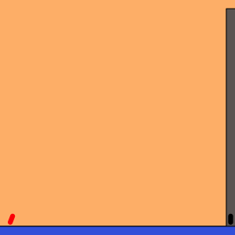

   How fast, in meters per second, is the shadow moving up the cliff? The tolerance is $\pm 10$ m/s.

#### Question

5. At sunset, the sun’s rays are parallel to the local flat ground. A rocket is launched at an angle of elevation of 52° above the horizon at a speed of 2190 meters per second. Its shadow is projected onto a tall vertical cliff to the east.

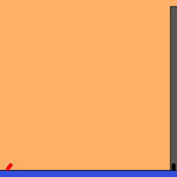

   How fast, in meters per second, is the shadow moving up the cliff? The tolerance is $\pm 10$ m/s.

#### Question

6. At sunset, the sun’s rays are parallel to the local flat ground. A rocket is launched at an angle of elevation of 29.1° above the horizon at a speed of 2530 meters per second. Its shadow is projected onto a tall vertical cliff to the east.

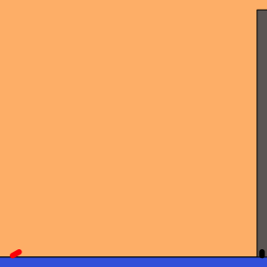

   How fast, in meters per second, is the shadow moving up the cliff? The tolerance is $\pm 10$ m/s.

#### Question

7. At sunset, the sun’s rays are parallel to the local flat ground. A rocket is launched at an angle of elevation of 55.1° above the horizon at a speed of 3150 meters per second. Its shadow is projected onto a tall vertical cliff to the east.

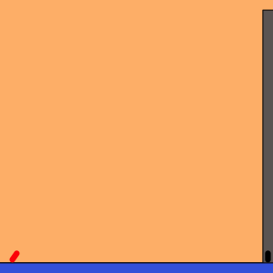

   How fast, in meters per second, is the shadow moving up the cliff? The tolerance is $\pm 10$ m/s.

#### Question

8. At sunset, the sun’s rays are parallel to the local flat ground. A rocket is launched at an angle of elevation of 59.6° above the horizon at a speed of 3490 meters per second. Its shadow is projected onto a tall vertical cliff to the east.

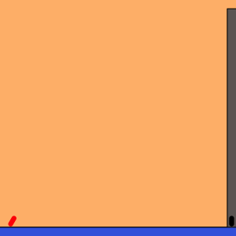

   How fast, in meters per second, is the shadow moving up the cliff? The tolerance is $\pm 10$ m/s.